# BNCI Assignment 2

#### Update of graph

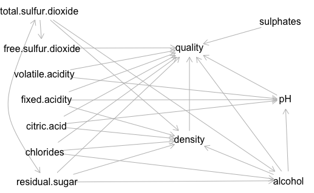

```r
graph_white_3 <- dagitty('dag {
bb="0,0,1,1"
alcohol [pos="0.673,0.581"]
chlorides [pos="0.233,0.498"]
citric.acid [pos="0.236,0.423"]
density [pos="0.494,0.464"]
fixed.acidity [pos="0.236,0.349"]
free.sulfur.dioxide [pos="0.228,0.200"]
pH [pos="0.667,0.348"]
quality [outcome,pos="0.494,0.199"]
residual.sugar [exposure,pos="0.237,0.585"]
sulphates [pos="0.658,0.125"]
total.sulfur.dioxide [pos="0.223,0.092"]
volatile.acidity [pos="0.232,0.276"]
alcohol -> density
alcohol -> pH
alcohol -> quality
chlorides -> alcohol
chlorides -> density
chlorides -> quality
citric.acid -> density
citric.acid -> pH
citric.acid -> quality
density -> quality
fixed.acidity -> density
fixed.acidity -> pH
fixed.acidity -> quality
free.sulfur.dioxide -> quality
total.sulfur.dioxide <-> residual.sugar [pos="0.140,0.380"]
pH -> quality
residual.sugar -> alcohol
residual.sugar -> density
residual.sugar -> quality
sulphates -> quality
total.sulfur.dioxide -> alcohol
total.sulfur.dioxide -> density
total.sulfur.dioxide -> free.sulfur.dioxide
volatile.acidity -> pH
volatile.acidity -> quality
}
')

plot(graph_white_3)
```

#### Test of fit of implicit latent variable total.sulfur.dioxide <-> residual.sugar

```r
CorM <- lavCor(data_normalized)
results <- localTests(graph_white_3, sample.cov = CorM, sample.nobs = nrow(data_normalized), abbreviate.names = FALSE)
results_ordered <- results[order(-abs(results$estimate), results$p.value),]
results_ordered
```

|  | estimate | p.value | 2.5% | 97.5% |
| --- | --- | --- | --- | --- |
| citric.acid _\|\|_ fixed.acidity | 0.288857550 | 4.363503e-96 | 0.263061816 | 0.314535774 |
| chlorides _\|\|_ total.sulfur.dioxide | 0.198815090 | 4.004245e-45 | 0.171772330 | 0.225607916 |
| pH _\|\|_ residual.sugar \| alcohol | -0.163899836 | 5.907327e-31 | -0.191052111 | -0.136517605 |
| pH _\|\|_ sulphates | 0.155550152 | 5.274248e-28 | 0.128101257 | 0.182776946 |
| citric.acid _\|\|_ volatile.acidity | -0.153332277 | 3.021562e-27 | -0.180579050 | -0.125865629 |
| density _\|\|_ pH \| alcohol, citric.acid, fixed.acidity | 0.136382624 | 8.165515e-22 | 0.108781410 | 0.163782642 |
| sulphates _\|\|_ total.sulfur.dioxide | 0.134425762 | 3.041171e-21 | 0.106819568 | 0.161833240 |
| alcohol _\|\|_ fixed.acidity | -0.121128560 | 1.657042e-17 | -0.148638475 | -0.093436724 |
| citric.acid _\|\|_ total.sulfur.dioxide | 0.120965183 | 1.831381e-17 | 0.093272359 | 0.148476301 |
| chlorides _\|\|_ citric.acid | 0.113860351 | 1.243838e-15 | 0.086126020 | 0.141422458 |

[output cut: 32 more lines]

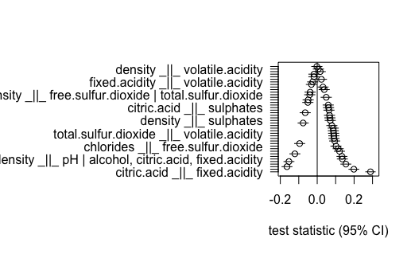

```r
plotLocalTestResults(results)
```

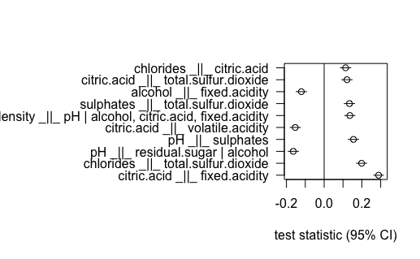

```r
plotLocalTestResults(results, n=10)
```

### Update 4: implicit latent variable citric.acid <-> fixed.acidity

#### Investigation of citric.acid <-> fixed.acidity

```r
# Plot 1: residual.sugar ~ total.sulfur.dioxide
plot(citric.acid ~ fixed.acidity, data = data_normalized, pch = 19)
model1 <- lm(citric.acid ~ fixed.acidity, data = data_normalized)
abline(model1, col = 2)
```

```r
# Extract and print coefficient and p-value
summary1 <- summary(model1)
print(summary1)
```

```
Call:
lm(formula = citric.acid ~ fixed.acidity, data = data_normalized)

Residuals:
    Min      1Q  Median      3Q     Max
-2.8803 -0.5599 -0.1408  0.3920 10.7733

Coefficients:
                Estimate Std. Error t value Pr(>|t|)
(Intercept)   -1.213e-15  1.368e-02    0.00        1
fixed.acidity  2.889e-01  1.368e-02   21.11   <2e-16 ***
---
Signif. codes:  0 ‘***’ 0.001 ‘**’ 0.01 ‘*’ 0.05 ‘.’ 0.1 ‘ ’ 1

Residual standard error: 0.9575 on 4895 degrees of freedom
Multiple R-squared:  0.08344,   Adjusted R-squared:  0.08325
F-statistic: 445.6 on 1 and 4895 DF,  p-value: < 2.2e-16
```

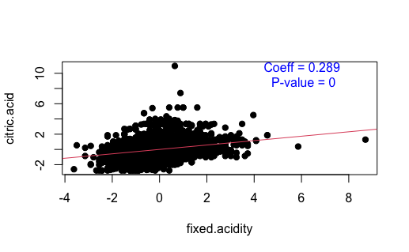

```r
coef1 <- summary1$coefficients["fixed.acidity", "Estimate"]
pval1 <- summary1$coefficients["fixed.acidity", "Pr(>|t|)"]
text(x = 0.7 * max(data_normalized$fixed.acidity),
     y = 0.9 * max(data_normalized$citric.acid),
     labels = paste("Coeff =", round(coef1, 3), "\nP-value =", round(pval1, 3)), col = "blue")
```

#### Graph update

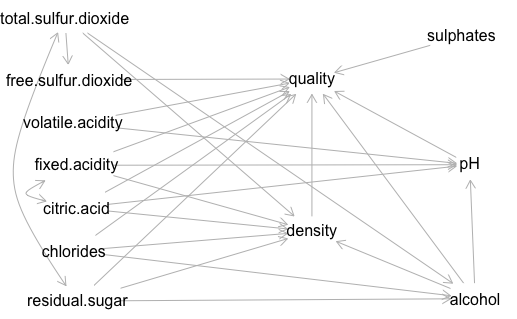

```r
graph_white_4 <- dagitty('dag {
bb="0,0,1,1"
alcohol [pos="0.673,0.581"]
chlorides [pos="0.233,0.498"]
citric.acid [pos="0.236,0.423"]
density [pos="0.494,0.464"]
fixed.acidity [pos="0.236,0.349"]
free.sulfur.dioxide [pos="0.228,0.200"]
pH [pos="0.667,0.348"]
quality [outcome,pos="0.494,0.199"]
residual.sugar [exposure,pos="0.237,0.585"]
sulphates [pos="0.658,0.125"]
total.sulfur.dioxide [pos="0.223,0.092"]
volatile.acidity [pos="0.232,0.276"]
alcohol -> density
alcohol -> pH
alcohol -> quality
chlorides -> alcohol
chlorides -> density
chlorides -> quality
citric.acid -> density
citric.acid -> pH
citric.acid -> quality
density -> quality
fixed.acidity -> density
fixed.acidity -> pH
fixed.acidity -> quality
fixed.acidity <-> citric.acid [pos="0.170,0.400"]
free.sulfur.dioxide -> quality
pH -> quality
residual.sugar -> alcohol
residual.sugar -> density
residual.sugar -> quality
sulphates -> quality
total.sulfur.dioxide -> alcohol
total.sulfur.dioxide -> density
total.sulfur.dioxide -> free.sulfur.dioxide
total.sulfur.dioxide <-> residual.sugar [pos="0.140,0.380"]
volatile.acidity -> pH
volatile.acidity -> quality
}
')

plot(graph_white_4)
```

#### Test of fit

```r
CorM <- lavCor(data_normalized)
results <- localTests(graph_white_4, sample.cov = CorM, sample.nobs = nrow(data_normalized), abbreviate.names = FALSE)
results_ordered <- results[order(-abs(results$estimate), results$p.value),]
results_ordered
```

|  | estimate | p.value | 2.5% | 97.5% |
| --- | --- | --- | --- | --- |
| chlorides _\|\|_ total.sulfur.dioxide | 0.198815090 | 4.004245e-45 | 0.171772330 | 0.225607916 |
| pH _\|\|_ residual.sugar \| alcohol | -0.163899836 | 5.907327e-31 | -0.191052111 | -0.136517605 |
| pH _\|\|_ sulphates | 0.155550152 | 5.274248e-28 | 0.128101257 | 0.182776946 |
| citric.acid _\|\|_ volatile.acidity | -0.153332277 | 3.021562e-27 | -0.180579050 | -0.125865629 |
| density _\|\|_ pH \| alcohol, citric.acid, fixed.acidity | 0.136382624 | 8.165515e-22 | 0.108781410 | 0.163782642 |
| sulphates _\|\|_ total.sulfur.dioxide | 0.134425762 | 3.041171e-21 | 0.106819568 | 0.161833240 |
| alcohol _\|\|_ fixed.acidity | -0.121128560 | 1.657042e-17 | -0.148638475 | -0.093436724 |
| citric.acid _\|\|_ total.sulfur.dioxide | 0.120965183 | 1.831381e-17 | 0.093272359 | 0.148476301 |
| chlorides _\|\|_ citric.acid | 0.113860351 | 1.243838e-15 | 0.086126020 | 0.141422458 |
| chlorides _\|\|_ free.sulfur.dioxide | 0.101860260 | 8.636747e-13 | 0.074062395 | 0.129502549 |

[output cut: 31 more lines]

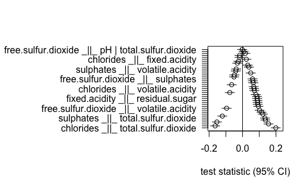

```r
plotLocalTestResults(results)
```

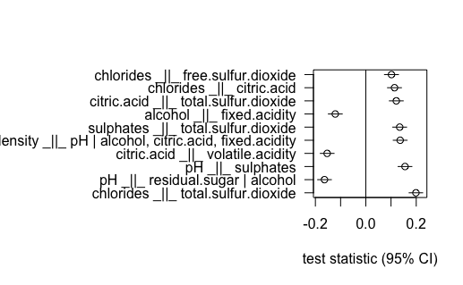

```r
plotLocalTestResults(results, n=10)
```

#### Fitting initial SEM

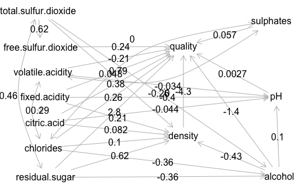

```r
# Note that there are several edges set 0 as they were implied by lavaan

lvsem <- "
density~alcohol
pH~alcohol
quality~alcohol
alcohol~chlorides
density~chlorides
quality~chlorides
density~citric.acid
pH~citric.acid
quality~citric.acid
citric.acid ~~ fixed.acidity
quality~density
density~fixed.acidity
pH~fixed.acidity
quality~fixed.acidity
quality~free.sulfur.dioxide
quality~pH
alcohol~residual.sugar
density~residual.sugar
quality~residual.sugar
total.sulfur.dioxide ~~ residual.sugar
quality~sulphates
alcohol~total.sulfur.dioxide
density~total.sulfur.dioxide
free.sulfur.dioxide~total.sulfur.dioxide
pH~volatile.acidity
quality~volatile.acidity

volatile.acidity ~~ 0*chlorides
volatile.acidity ~~ 0*sulphates
sulphates ~~ 0*chlorides
"

lvsem.fit <- sem(lvsem, data_normalized)
cg <- coordinates(graph_white_4)
fg <- lavaanToGraph(lvsem.fit, digits=2)
coordinates(fg) <- cg
plot(fg, show.coefficients=TRUE)
```

```r
# Extract all parameter estimates
params <- parameterEstimates(lvsem.fit)

# Filter for both regression (~) and bidirectional (~~) paths
edge_coeffs <- params[params$op %in% c("~", "~~"), ]

# Sort by magnitude in ascending order
edge_coeffs_sorted <- edge_coeffs[order(abs(edge_coeffs$est)), ]

# Display relevant columns (lhs, rhs, estimate)
edge_coeffs_sorted[, c("lhs", "rhs", "est")]
```

|  | lhs | rhs | est |
| --- | --- | --- | --- |
| 27 | chlorides | volatile.acidity | 0.000 |
| 28 | sulphates | volatile.acidity | 0.000 |
| 29 | chlorides | sulphates | 0.000 |
| 36 | density | density | 0.001 |
| 16 | quality | pH | 0.003 |
| 25 | pH | volatile.acidity | -0.034 |
| 8 | pH | citric.acid | -0.044 |
| 23 | density | total.sulfur.dioxide | 0.048 |
| 21 | quality | sulphates | 0.057 |
| 7 | density | citric.acid | 0.082 |

[output cut: 31 more lines]

Pruning was done on in combinations of causal effects.

### Calculating main causal effects

#### General covariance matrix

```r
graph_white_inference <- lavaanToGraph(lvsem.fit)
#print(graph_white_inference)
imCovM <- impliedCovarianceMatrix(graph_white_inference)
```

Sanity check: Sulphates has no parents. Therefore a simple linear model should get similar results than what inference on our fitted graph finds.

```r
print(lm(quality ~ sulphates, data_normalized))
```

```
Call:
lm(formula = quality ~ sulphates, data = data_normalized)

Coefficients:
(Intercept)    sulphates
    3.87788      0.04752
```

```r
print(impliedCovarianceMatrix( graph_white_inference)['sulphates','quality'])
```

```
[1] 0.0573
```

seems good, its in the same magnitude. But weird it has a different value

#### Function to create interventional graph

```r
# Function to create interventional graph
create_interventional_graph <- function(original_graph, variable_of_interest) {
  # Parse the original graph
  g <- dagitty(original_graph)

  # Extract node positions
  nodes <- names(g)
  coords <- coordinates(g)
  node_positions <- sapply(nodes, function(node) {
    sprintf('%s [pos="%.3f,%.3f"]', node, coords$x[node], coords$y[node])
  })

  # Extract edges and beta coefficients from the original graph string
  # Pattern to match: v ->|<-> w [beta="value"]
  beta_pattern <- "([a-zA-Z._]+) (->|<->) ([a-zA-Z._]+) \\[beta=\"([-0-9.e]+)\"\\]"
  betas <- stringr::str_match_all(original_graph, beta_pattern)[[1]]
  edges <- data.frame(v = betas[, 2], w = betas[, 4], e = betas[,3], beta = betas[, 5], stringsAsFactors = FALSE)

  # Filter out incoming edges to the variable of interest
  adjusted_edges <- edges[!(edges$e == "->" & edges$w == variable_of_interest), ]

  # Check for bidirectional edges and remove the ones involving the variable of interest
  bidirectional_edges <- edges[edges$e == "<->",]
  adjusted_bidirectional_edges <- bidirectional_edges[!(bidirectional_edges$v == variable_of_interest | bidirectional_edges$w == variable_of_interest), ]

  # Combine directed and filtered bidirectional edges
  adjusted_edges <- rbind(
    adjusted_edges[adjusted_edges$e == "->", ],
    adjusted_bidirectional_edges
  )

  # Create the adjusted DAG string
  interventional_graph <- sprintf("dag {\n%s\n}",
                          paste(
                            node_positions,
                            paste0(
                              apply(adjusted_edges, 1, function(row) {
                                if (row["e"] == "->") {
                                  sprintf("%s -> %s [beta=\"%s\"]", row["v"], row["w"], row["beta"])
                                } else {
                                  sprintf("%s <-> %s [beta=\"%s\"]", row["v"], row["w"], row["beta"])
                                }
                              }),
                              collapse = "\n"
                            ),
                            collapse = "\n"
                          ))

  return(dagitty(interventional_graph))
}
```

#### Testing the interventional graph function

```r
# Generate interventional graph for "fixed.acidity"
intervention_graph <- create_interventional_graph(fg, "density")
cat(fg) #original graph
```

```
dag {
alcohol [pos="0.673,0.581"]
chlorides [pos="0.233,0.498"]
citric.acid [pos="0.236,0.423"]
density [pos="0.494,0.464"]
fixed.acidity [pos="0.236,0.349"]
free.sulfur.dioxide [pos="0.228,0.200"]
pH [pos="0.667,0.348"]
quality [pos="0.494,0.199"]
residual.sugar [pos="0.237,0.585"]
sulphates [pos="0.658,0.125"]
total.sulfur.dioxide [pos="0.223,0.092"]
volatile.acidity [pos="0.232,0.276"]
alcohol -> density [beta="-0.43"]
alcohol -> pH [beta="0.1"]
alcohol -> quality [beta="-1.4"]
chlorides -> alcohol [beta="-0.36"]
chlorides -> density [beta="0.1"]
chlorides -> quality [beta="0.26"]
chlorides <-> sulphates [beta="0"]
chlorides <-> volatile.acidity [beta="0"]
citric.acid -> density [beta="0.082"]
citric.acid -> pH [beta="-0.044"]
citric.acid -> quality [beta="0.38"]
citric.acid <-> fixed.acidity [beta="0.29"]
density -> quality [beta="-4.3"]
fixed.acidity -> density [beta="0.21"]
fixed.acidity -> pH [beta="-0.4"]
fixed.acidity -> quality [beta="0.79"]
free.sulfur.dioxide -> quality [beta="0.24"]
pH -> quality [beta="0.0027"]
residual.sugar -> alcohol [beta="-0.36"]
residual.sugar -> density [beta="0.62"]
residual.sugar -> quality [beta="2.8"]
residual.sugar <-> total.sulfur.dioxide [beta="0.46"]
sulphates -> quality [beta="0.057"]
sulphates <-> volatile.acidity [beta="0"]
total.sulfur.dioxide -> alcohol [beta="-0.26"]
total.sulfur.dioxide -> density [beta="0.048"]
total.sulfur.dioxide -> free.sulfur.dioxide [beta="0.62"]
volatile.acidity -> pH [beta="-0.034"]
volatile.acidity -> quality [beta="-0.21"]
}
```

```r
cat(intervention_graph)
```

```
dag {
alcohol [pos="0.673,0.581"]
chlorides [pos="0.233,0.498"]
citric.acid [pos="0.236,0.423"]
density [pos="0.494,0.464"]
fixed.acidity [pos="0.236,0.349"]
free.sulfur.dioxide [pos="0.228,0.200"]
pH [pos="0.667,0.348"]
quality [pos="0.494,0.199"]
residual.sugar [pos="0.237,0.585"]
sulphates [pos="0.658,0.125"]
total.sulfur.dioxide [pos="0.223,0.092"]
volatile.acidity [pos="0.232,0.276"]
alcohol -> pH [beta="0.1"]
alcohol -> quality [beta="-1.4"]
chlorides -> alcohol [beta="-0.36"]
chlorides -> quality [beta="0.26"]
chlorides <-> sulphates [beta="0"]
chlorides <-> volatile.acidity [beta="0"]
citric.acid -> pH [beta="-0.044"]
citric.acid -> quality [beta="0.38"]
citric.acid <-> fixed.acidity [beta="0.29"]
density -> quality [beta="-4.3"]
fixed.acidity -> pH [beta="-0.4"]
fixed.acidity -> quality [beta="0.79"]
free.sulfur.dioxide -> quality [beta="0.24"]
pH -> quality [beta="0.0027"]
residual.sugar -> alcohol [beta="-0.36"]
residual.sugar -> quality [beta="2.8"]
residual.sugar <-> total.sulfur.dioxide [beta="0.46"]
sulphates -> quality [beta="0.057"]
sulphates <-> volatile.acidity [beta="0"]
total.sulfur.dioxide -> alcohol [beta="-0.26"]
total.sulfur.dioxide -> free.sulfur.dioxide [beta="0.62"]
volatile.acidity -> pH [beta="-0.034"]
volatile.acidity -> quality [beta="-0.21"]
}
```

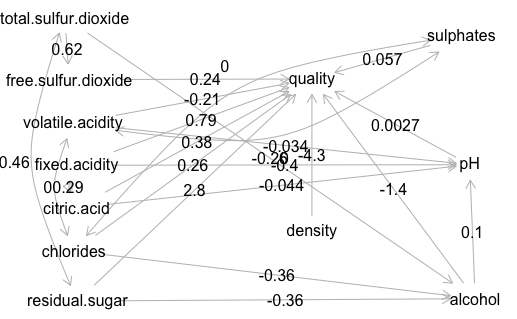

```r
plot(intervention_graph, show.coefficients = TRUE)
```

#### Calculating causal effects

```r
nodes <- names(fg)
# Initialize a data frame to store the results
causal_effects <- data.frame(
  Variable = character(),  # To store variable names
  CausalEffect = numeric() # To store causal effects
)

# Iterate over the nodes, skipping the "quality" variable
for (node in nodes) {
  if (node == "quality") next  # Skip the "quality" variable

  # Create the intervention graph
  intervention_graph <- create_interventional_graph(fg, node)

  # Calculate the causal effect of the node on quality
  causal_effect <- impliedCovarianceMatrix(intervention_graph)[node, 'quality']

  # Append the result to the data frame
  causal_effects <- rbind(causal_effects, data.frame(Variable = node, CausalEffect = causal_effect))
}

# Print the final data frame
#print(causal_effects)
ce_ordered <- causal_effects[order(-abs(causal_effects$CausalEffect)),]
print(ce_ordered)
```

|  | Variable | CausalEffect |
| --- | --- | --- |
| 4 | density | -4.3000000 |
| 1 | alcohol | 0.4492700 |
| 2 | chlorides | -0.3317372 |
| 6 | free.sulfur.dioxide | 0.2400000 |
| 11 | volatile.acidity | -0.2100918 |
| 10 | total.sulfur.dioxide | -0.1744102 |
| 5 | fixed.acidity | -0.1140800 |
| 9 | sulphates | 0.0570000 |
| 8 | residual.sugar | -0.0277372 |
| 3 | citric.acid | 0.0272812 |

[output cut: 1 more lines]

Therefore our first research question is answered. Listed are the causal effects sorted by size of influence. - Alcohol seems in line with what other researcher found. As alcohol was always in the top rankings of importance - density is surprising - volatile acidity also seems logical. Acetic acid makes wine taste like vinegar. Its an indicator for spoiled wine. A strong negative effect seems logical though - A negative effect of total.sulfur.dioxide also seems reasonable as sulfuric compounds are normally perceived as not pleasant (e.g. rotting eggs smell is due to sulfur compounds) - Surprising are citric.acid and residual.sugar and their low scores as these play a large role for the taste of wine. But I guess if the wine is sweet or acidic does not automatically indicate if its good or bad quality but has more characterizing property.

Using polychoric correlations changed some of this: - now density has overly large contribution. This does not make much sense. - free.sulfur.dioxide is listed with a positive causal effect which is weird. See the interpretation of total.sulfur dioxide - pH has a very low coefficient in the causal effect as well as the SEM model. As the acids in the wine directly influence the quality (in taste in acidity) it makes sense to exclude the relation pH -> quality. It then ends up as a collider in the network which also is logical as it is a mathematical measure of the total acids presents. - I would restrain to remove other edges as these are thought to give taste characteristics to the wine. It is informative to know if their effect is small or large.

### SEM Refitting without pH

```r
# Now pH is also set to 0

lvsem <- "
density~alcohol
pH~alcohol
quality~alcohol
alcohol~chlorides
density~chlorides
quality~chlorides
density~citric.acid
pH~citric.acid
quality~citric.acid
citric.acid ~~ fixed.acidity
quality~density
density~fixed.acidity
pH~fixed.acidity
quality~fixed.acidity
quality~free.sulfur.dioxide

pH ~~ 0*quality

alcohol~residual.sugar
density~residual.sugar
quality~residual.sugar
total.sulfur.dioxide ~~ residual.sugar
quality~sulphates
alcohol~total.sulfur.dioxide
density~total.sulfur.dioxide
free.sulfur.dioxide~total.sulfur.dioxide
pH~volatile.acidity
quality~volatile.acidity

volatile.acidity ~~ 0*chlorides
volatile.acidity ~~ 0*sulphates
sulphates ~~ 0*chlorides
"

lvsem.fit <- sem(lvsem, data_normalized)
summary(lvsem.fit)
```

```
lavaan 0.6-18 ended normally after 107 iterations

  Estimator                                       DWLS
  Optimization method                           NLMINB
  Number of model parameters                        53

  Number of observations                          4897

Model Test User Model:
                                              Standard      Scaled
  Test Statistic                              2221.804    1795.384
  Degrees of freedom                                41          41
  P-value (Chi-square)                           0.000       0.000
  Scaling correction factor                                  1.246
  Shift parameter                                           12.878
    simple second-order correction

Parameter Estimates:

  Parameterization                               Delta
  Standard errors                           Robust.sem
  Information                                 Expected
  Information saturated (h1) model        Unstructured

Regressions:
                        Estimate  Std.Err  z-value  P(>|z|)
  density ~
    alcohol               -0.434    0.007  -63.403    0.000
  pH ~
    alcohol                0.105    0.015    6.906    0.000
  quality ~
    alcohol               -1.426    0.286   -4.980    0.000
  alcohol ~
    chlorides             -0.361    0.005  -76.743    0.000
  density ~
    chlorides              0.103    0.006   18.068    0.000
  quality ~
    chlorides              0.262    0.059    4.413    0.000
  density ~
    citric.acid            0.082    0.013    6.247    0.000
```

[output cut: 67 more lines]

```

Variances:
                   Estimate  Std.Err  z-value  P(>|z|)
   .density           0.001    0.001    0.971    0.332
   .pH                0.818    0.016   52.337    0.000
   .quality           0.628
   .alcohol           0.590    0.017   35.653    0.000
   .free.sulfr.dxd    0.619    0.007   87.101    0.000
    chlorides         1.000    0.008  132.327    0.000
    citric.acid       1.000    0.011   89.456    0.000
    fixed.acidity     1.007    0.015   68.147    0.000
    residual.sugar    0.993    0.027   37.216    0.000
    sulphates         1.000    0.018   56.807    0.000
    total.slfr.dxd    0.998    0.020   49.733    0.000
    volatile.acdty    1.000    0.014   73.658    0.000
```

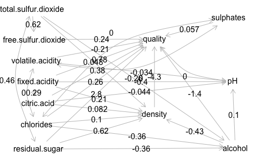

```r
cg <- coordinates(graph_white_4)
fg <- lavaanToGraph(lvsem.fit, digits=2)
coordinates(fg) <- cg
plot(fg, show.coefficients=TRUE)
```

#### Test of fit

```r
CorM <- lavCor(data_normalized)
results <- localTests(graph_white_4, sample.cov = CorM, sample.nobs = nrow(data_normalized), abbreviate.names = FALSE)
results_ordered <- results[order(-abs(results$estimate), results$p.value),]
results_ordered
```

|  | estimate | p.value | 2.5% | 97.5% |
| --- | --- | --- | --- | --- |
| chlorides _\|\|_ total.sulfur.dioxide | 0.198815090 | 4.004245e-45 | 0.171772330 | 0.225607916 |
| pH _\|\|_ residual.sugar \| alcohol | -0.163899836 | 5.907327e-31 | -0.191052111 | -0.136517605 |
| pH _\|\|_ sulphates | 0.155550152 | 5.274248e-28 | 0.128101257 | 0.182776946 |
| citric.acid _\|\|_ volatile.acidity | -0.153332277 | 3.021562e-27 | -0.180579050 | -0.125865629 |
| density _\|\|_ pH \| alcohol, citric.acid, fixed.acidity | 0.136382624 | 8.165515e-22 | 0.108781410 | 0.163782642 |
| sulphates _\|\|_ total.sulfur.dioxide | 0.134425762 | 3.041171e-21 | 0.106819568 | 0.161833240 |
| alcohol _\|\|_ fixed.acidity | -0.121128560 | 1.657042e-17 | -0.148638475 | -0.093436724 |
| citric.acid _\|\|_ total.sulfur.dioxide | 0.120965183 | 1.831381e-17 | 0.093272359 | 0.148476301 |
| chlorides _\|\|_ citric.acid | 0.113860351 | 1.243838e-15 | 0.086126020 | 0.141422458 |
| chlorides _\|\|_ free.sulfur.dioxide | 0.101860260 | 8.636747e-13 | 0.074062395 | 0.129502549 |

[output cut: 31 more lines]

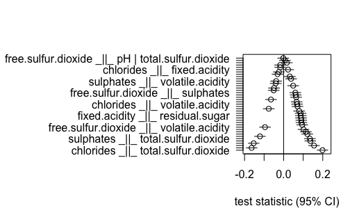

```r
plotLocalTestResults(results)
par(mar = c(5, 20, 4, 2))
```

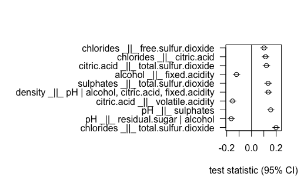

```r
plotLocalTestResults(results, n=10, auto.margin=FALSE)
```

#### Model coefficients

```r
# Extract all parameter estimates
params <- parameterEstimates(lvsem.fit)

# Filter for both regression (~) and bidirectional (~~) paths
edge_coeffs <- params[params$op %in% c("~", "~~"), ]

# Sort by magnitude in ascending order
edge_coeffs_sorted <- edge_coeffs[order(abs(edge_coeffs$est)), ]

# Display relevant columns (lhs, rhs, estimate)
edge_coeffs_sorted[, c("lhs", "rhs", "est")]
```

|  | lhs | rhs | est |
| --- | --- | --- | --- |
| 16 | pH | quality | 0.000 |
| 27 | chlorides | volatile.acidity | 0.000 |
| 28 | sulphates | volatile.acidity | 0.000 |
| 29 | chlorides | sulphates | 0.000 |
| 36 | density | density | 0.001 |
| 25 | pH | volatile.acidity | -0.034 |
| 8 | pH | citric.acid | -0.044 |
| 23 | density | total.sulfur.dioxide | 0.048 |
| 21 | quality | sulphates | 0.057 |
| 7 | density | citric.acid | 0.082 |

[output cut: 31 more lines]

#### Recalculating Causal Effects

```r
nodes <- names(fg)
# Initialize a data frame to store the results
causal_effects <- data.frame(
  Variable = character(),  # To store variable names
  CausalEffect = numeric() # To store causal effects
)

# Iterate over the nodes, skipping the "quality" variable
for (node in nodes) {
  if (node == "quality") next  # Skip the "quality" variable

  # Create the intervention graph
  intervention_graph <- create_interventional_graph(fg, node)

  # Calculate the causal effect of the node on quality
  causal_effect <- impliedCovarianceMatrix(intervention_graph)[node, 'quality']

  # Append the result to the data frame
  causal_effects <- rbind(causal_effects, data.frame(Variable = node, CausalEffect = causal_effect))
}

# Print the final data frame
#print(causal_effects)
ce_ordered <- causal_effects[order(-abs(causal_effects$CausalEffect)),]
ce_ordered$CausalEffect <- round(ce_ordered$CausalEffect, 3)
print(ce_ordered)
```

|  | Variable | CausalEffect |
| --- | --- | --- |
| 4 | density | -4.300 |
| 1 | alcohol | 0.449 |
| 2 | chlorides | -0.332 |
| 6 | free.sulfur.dioxide | 0.240 |
| 11 | volatile.acidity | -0.210 |
| 10 | total.sulfur.dioxide | -0.174 |
| 5 | fixed.acidity | -0.123 |
| 9 | sulphates | 0.057 |
| 8 | residual.sugar | -0.028 |
| 3 | citric.acid | 0.027 |

[output cut: 1 more lines]

#### Interpretation of causal effects

```r
# Initialize a data frame for denormalized causal effects
denormalized_effects <- data.frame(
  Variable = character(),           # Parent variables
  NormalizedEffect = numeric(),   # Normalized causal effect
  parent_sd_raw = numeric(),
  DenormalizedEffect = numeric()  # Denormalized causal effect
)

# Iterate over the variables (assuming causal_effects is your calculated data frame)

for (i in 1:nrow(causal_effects)) {
  parent <- causal_effects$Variable[i]
  #print(parent)
  normalized_effect <- causal_effects$CausalEffect[i]

  # Get the standard deviation of the parent variable
  #print(c(data_raw[parent]))
  parent_sd <- sd(data_raw[[parent]])
  #print(parent_sd)

  # Get the standard deviation of the quality variable
  child_sd <- sd(as.numeric(data_raw$quality))  # Treat quality as numeric for SD

  # Denormalize the effect
  denormalized_effect <- normalized_effect * parent_sd / child_sd

  # Append to the data frame
  denormalized_effects <- rbind(denormalized_effects,
                                data.frame(
                                  Variable = parent,
                                  NormalizedEffect = normalized_effect,
                                  parent_sd_raw = parent_sd,
                                  DenormalizedEffect = denormalized_effect
                                ))
}

# Round results to three decimals
denormalized_effects$NormalizedEffect <- round(denormalized_effects$NormalizedEffect, 3)
denormalized_effects$parent_sd_raw <- round(denormalized_effects$parent_sd_raw, 3)
denormalized_effects$DenormalizedEffect <- round(denormalized_effects$DenormalizedEffect, 3)

# Sort by the absolute value of the normalized effect
denormalized_effects <- denormalized_effects[order(-abs(denormalized_effects$NormalizedEffect)), ]

# Print the denormalized causal effects
print(denormalized_effects)
```

|  | Variable | NormalizedEffect | parent_sd_raw | DenormalizedEffect |
| --- | --- | --- | --- | --- |
| 4 | density | -4.300 | 0.003 | -0.015 |
| 1 | alcohol | 0.449 | 1.231 | 0.624 |
| 2 | chlorides | -0.332 | 0.022 | -0.008 |
| 6 | free.sulfur.dioxide | 0.240 | 17.007 | 4.609 |
| 11 | volatile.acidity | -0.210 | 0.101 | -0.024 |
| 10 | total.sulfur.dioxide | -0.174 | 42.498 | -8.366 |
| 5 | fixed.acidity | -0.123 | 0.844 | -0.117 |
| 9 | sulphates | 0.057 | 0.114 | 0.007 |
| 8 | residual.sugar | -0.028 | 5.072 | -0.158 |
| 3 | citric.acid | 0.027 | 0.121 | 0.004 |

[output cut: 1 more lines]

### Structure Learning

```r
variable_names <- names(data_raw)
print(variable_names)
```

```
 [1] "fixed.acidity"        "volatile.acidity"     "citric.acid"          "residual.sugar"
 [5] "chlorides"            "free.sulfur.dioxide"  "total.sulfur.dioxide" "density"
 [9] "pH"                   "sulphates"            "alcohol"              "quality"
```

```r
library(bnlearn)

whitelist <- data.frame(
  from = c('alcohol'),
  to = c('quality')
)

quality_strings <- c('quality', 'quality', 'quality', 'quality', 'quality',
                     'quality', 'quality', 'quality', 'quality', 'quality',
                     'quality', 'quality')
to_strings <- names(data_raw) # all variables
blacklist <- data.frame(
  from = quality_strings,
  to = to_strings
)

print(whitelist)
```

| from | to |
| --- | --- |
| alcohol | quality |

```r
fit <- pc.stable(data_normalized, whitelist = whitelist, blacklist = blacklist)
```

```
Error in check.arcs.against.assumptions(whitelist, data, criterion) :
  arc alcohol -> quality violates the assumptions of the model.
```

[figure not shown]

```r
plot(fit)
```